# Homework #3 (40 pts)

Jaideep B

## Instructions

- If you wish to use any additional packages beyond “Base R” (the default) then email Jericho (`jlaws011@ucr.edu`) for permission.
- Use R to answer the questions below.
- Check Canvas regularly for clarification on questions.

## Questions

**Q1: Plotting with Data (Iris)**

1. Create a histogram of sepal lengths from the `iris` data set. Make sure your histogram has an informative title, axis names, and a non-defaulted color.

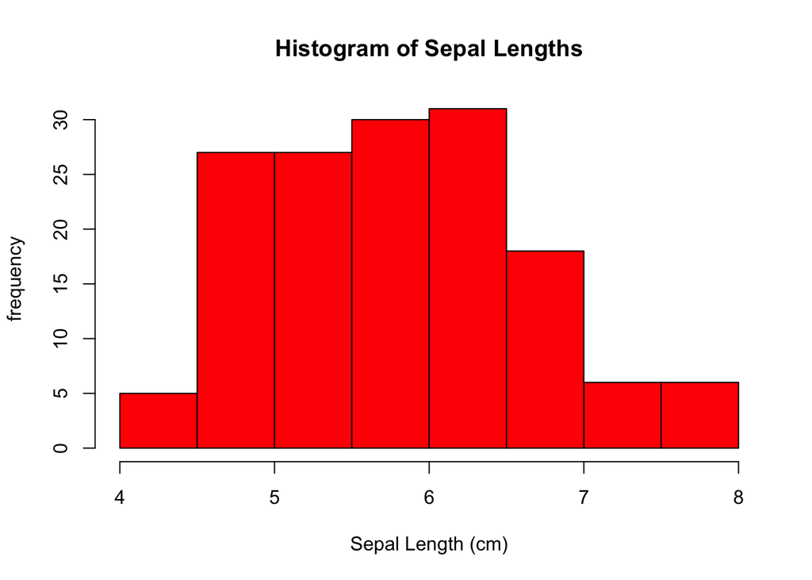

```r
data(iris)
hist(iris$Sepal.Length, main = "Histogram of Sepal Lengths", xlab = "Sepal Length (cm)", ylab = "frequency", col = "red")
```

2. Create a scatter plot, with sepal length on the x-axis and sepal width on the y-axis. Have the points colored based on the `Species` type. Add a legend, informative title, and axis labels to your scatter plot.

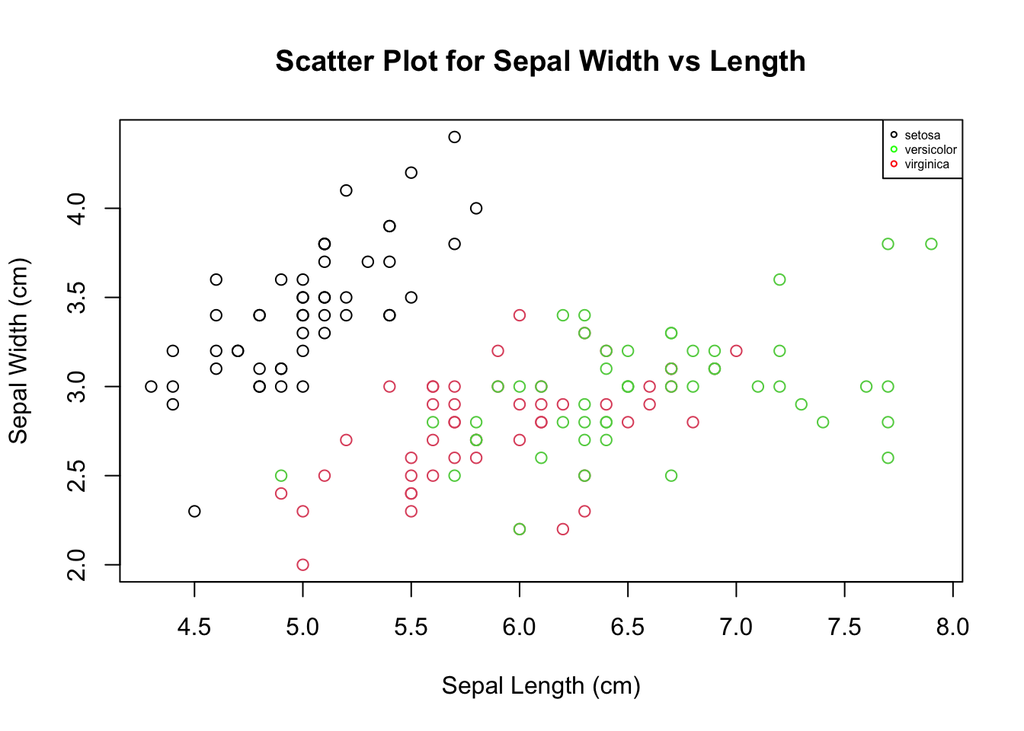

```r
plot(iris$Sepal.Length, iris$Sepal.Width, main = "Scatter Plot for Sepal Width vs Length", xlab = "Sepal Length (cm)", ylab = "Sepal Width (cm)", col = iris$Species)

legend("topright", legend = c("setosa", "versicolor", "virginica"), col = c("black", "green", "red"), cex = 0.5, pch = 1)
```

3. Create a box plot of petal lengths, grouped by the species of the flower. Make sure your box plot has an informative title, axis names, and a non-defaulted color.

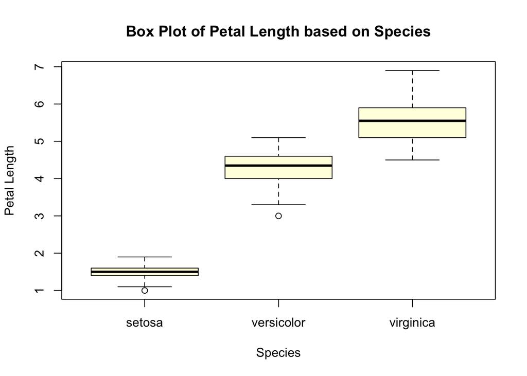

```r
boxplot(iris$Petal.Length ~ iris$Species, main = "Box Plot of Petal Length based on Species", xlab = "Species", ylab = "Petal Length", col = "lightyellow")
```

**Q2: Base R Graphics**

For this homework problem, we will be using the `22_23_nba_pergame.csv` file on Canvas. Make sure to load this file into your environment and name the dataset `nba`.

1. Write 5-7 sentences about some of the characteristics, summaries, and patterns you see in the `nba` data set. Some things you can talk about include the dimensions of the data set, how certain variables are distributed, and information that is included in the data set. Use code to back up and accompany the statements you make.

```r
nba <- read.csv("22_23_nba_pergame.csv")
nba
```

```
##      Rk                   Player   Pos Age  Tm  G GS   MP   FG  FGA   FG. X3P
## 1     1         Precious Achiuwa     C  23 TOR 55 12 20.7  3.6  7.3 0.485 0.5
## 2     2             Steven Adams     C  29 MEM 42 42 27.0  3.7  6.3 0.597 0.0
## 3     3              Bam Adebayo     C  25 MIA 75 75 34.6  8.0 14.9 0.540 0.0
## 4     4             Ochai Agbaji    SG  22 UTA 59 22 20.5  2.8  6.5 0.427 1.4
## 5     5             Santi Aldama    PF  22 MEM 77 20 21.8  3.2  6.8 0.470 1.2
## 6     6 Nickeil Alexander-Walker    SG  24 TOT 59  3 15.0  2.2  5.0 0.444 1.0
## 7     7            Grayson Allen    SG  27 MIL 72 70 27.4  3.4  7.7 0.440 2.0
## 8     8            Jarrett Allen     C  24 CLE 68 68 32.6  5.9  9.2 0.644 0.0
## 9     9            Jose Alvarado    PG  24 NOP 61 10 21.5  3.3  8.0 0.411 1.4
## 10   10            Kyle Anderson    PF  29 MIN 69 46 28.4  3.7  7.2 0.509 0.6
## 11   11    Giannis Antetokounmpo    PF  28 MIL 63 63 32.1 11.2 20.3 0.553 0.7
## 12   12   Thanasis Antetokounmpo    PF  30 MIL 37  0  5.6  0.5  1.2 0.435 0.0
## 13   13             Cole Anthony    PG  22 ORL 60  4 25.9  4.6 10.2 0.454 1.3
## 14   14               OG Anunoby    SF  25 TOR 67 67 35.6  6.3 13.2 0.476 2.1
```

[output cut: 1605 more lines]

```r
colnames(nba)
```

```
##  [1] "Rk"                "Player"            "Pos"
##  [4] "Age"               "Tm"                "G"
##  [7] "GS"                "MP"                "FG"
## [10] "FGA"               "FG."               "X3P"
## [13] "X3PA"              "X3P."              "X2P"
## [16] "X2PA"              "X2P."              "eFG."
## [19] "FT"                "FTA"               "FT."
## [22] "ORB"               "DRB"               "TRB"
## [25] "AST"               "STL"               "BLK"
## [28] "TOV"               "PF"                "PTS"
## [31] "Player.additional"
```

```r
length(colnames(nba))
```

```
## [1] 31
```

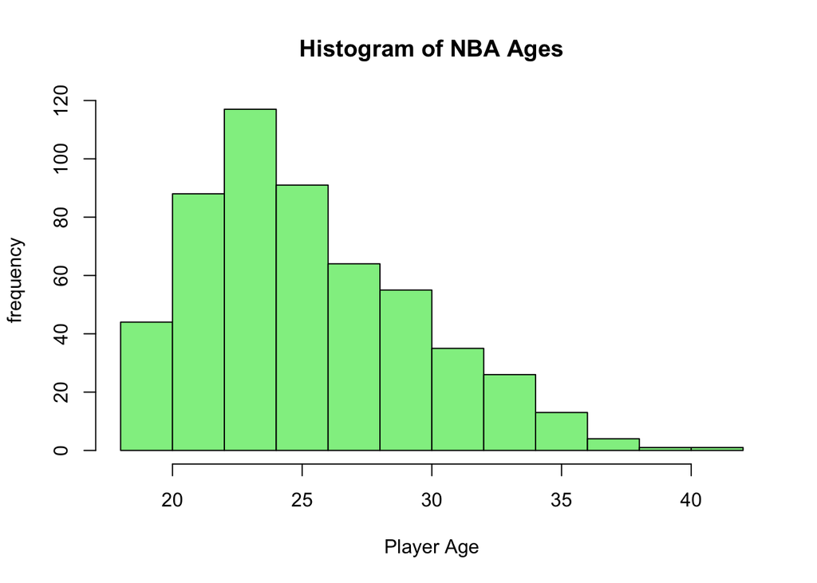

```r
hist(nba$Age, main = "Histogram of NBA Ages", xlab = "Player Age", ylab = "frequency", col = "lightgreen")
```

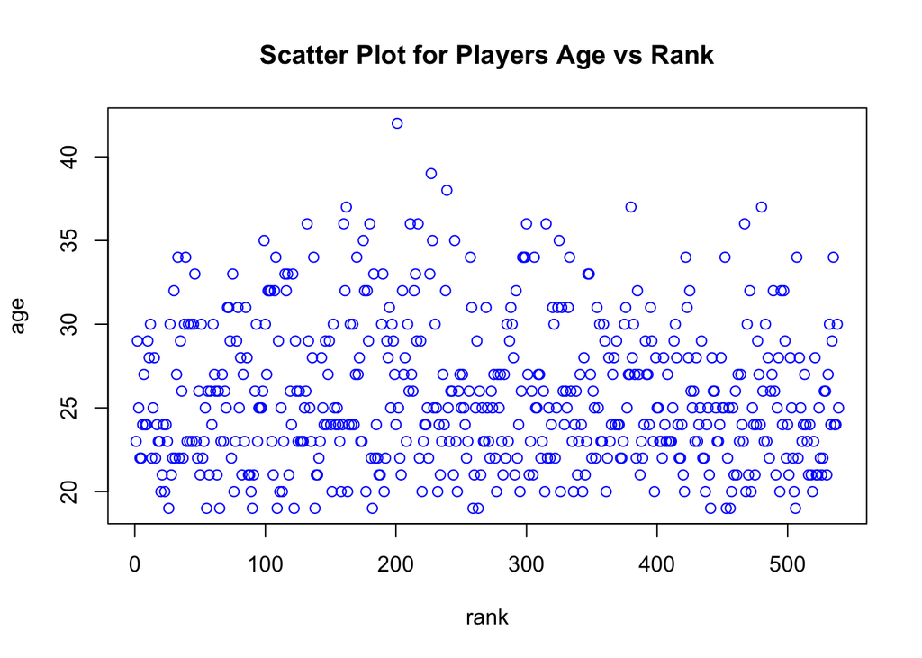

```r
plot(nba$Age, nba$Rank, main = "Scatter Plot for Players Age vs Rank", xlab = "rank", ylab = "age", col = "blue")
```

The nba dataset gives information on a variety of characters in the nba and is seemingly ordered descendingly by player rank. It has a variety of variables in relation to the nba players information with some of them including the players position, age, team affiliation, etc. The dataset has information on a total of 539 players with 31 different variables based on information on the player. The majority of the variables in relation to the players performance metrics seems to be of the double datatype. From the histogram on players ages, we can see that the age catagory that the majority of players fall into would be somewhere in between 20 and 25 with the frequency of nba players being active at higher ages getting progressively lower.

2. Create a new data set that is a subset of the `nba` data set, which only contains the following positions: `PG, SG, SF, PF, C`. Thereafter, convert the `Pos` column into a column of factors and remove any rows that contain NAs. Call this new data set `nba_five`.

```r
nba_five <- subset(nba, pos = "PG" & "SG" & "SF" & "PF" & "C")
nba_five$Pos <- factor(nba_five$Pos)
nba_five <- na.omit(nba_five)
nba_five
```

```
##      Rk                   Player   Pos Age  Tm  G GS   MP   FG  FGA   FG. X3P
## 1     1         Precious Achiuwa     C  23 TOR 55 12 20.7  3.6  7.3 0.485 0.5
## 2     2             Steven Adams     C  29 MEM 42 42 27.0  3.7  6.3 0.597 0.0
## 3     3              Bam Adebayo     C  25 MIA 75 75 34.6  8.0 14.9 0.540 0.0
## 4     4             Ochai Agbaji    SG  22 UTA 59 22 20.5  2.8  6.5 0.427 1.4
## 5     5             Santi Aldama    PF  22 MEM 77 20 21.8  3.2  6.8 0.470 1.2
## 6     6 Nickeil Alexander-Walker    SG  24 TOT 59  3 15.0  2.2  5.0 0.444 1.0
## 7     7            Grayson Allen    SG  27 MIL 72 70 27.4  3.4  7.7 0.440 2.0
## 8     8            Jarrett Allen     C  24 CLE 68 68 32.6  5.9  9.2 0.644 0.0
## 9     9            Jose Alvarado    PG  24 NOP 61 10 21.5  3.3  8.0 0.411 1.4
## 10   10            Kyle Anderson    PF  29 MIN 69 46 28.4  3.7  7.2 0.509 0.6
## 11   11    Giannis Antetokounmpo    PF  28 MIL 63 63 32.1 11.2 20.3 0.553 0.7
## 12   12   Thanasis Antetokounmpo    PF  30 MIL 37  0  5.6  0.5  1.2 0.435 0.0
## 13   13             Cole Anthony    PG  22 ORL 60  4 25.9  4.6 10.2 0.454 1.3
## 14   14               OG Anunoby    SF  25 TOR 67 67 35.6  6.3 13.2 0.476 2.1
```

[output cut: 1494 more lines]

3. Using base R and the data set `nba_five`, create side-by-side boxplots of the `MP` variable broken up by `Pos` (the different positions). Make sure you have an informative title, appropriate axis labels, and colors. Use the argument `col` so that *each boxplot is a different color* of your choice.

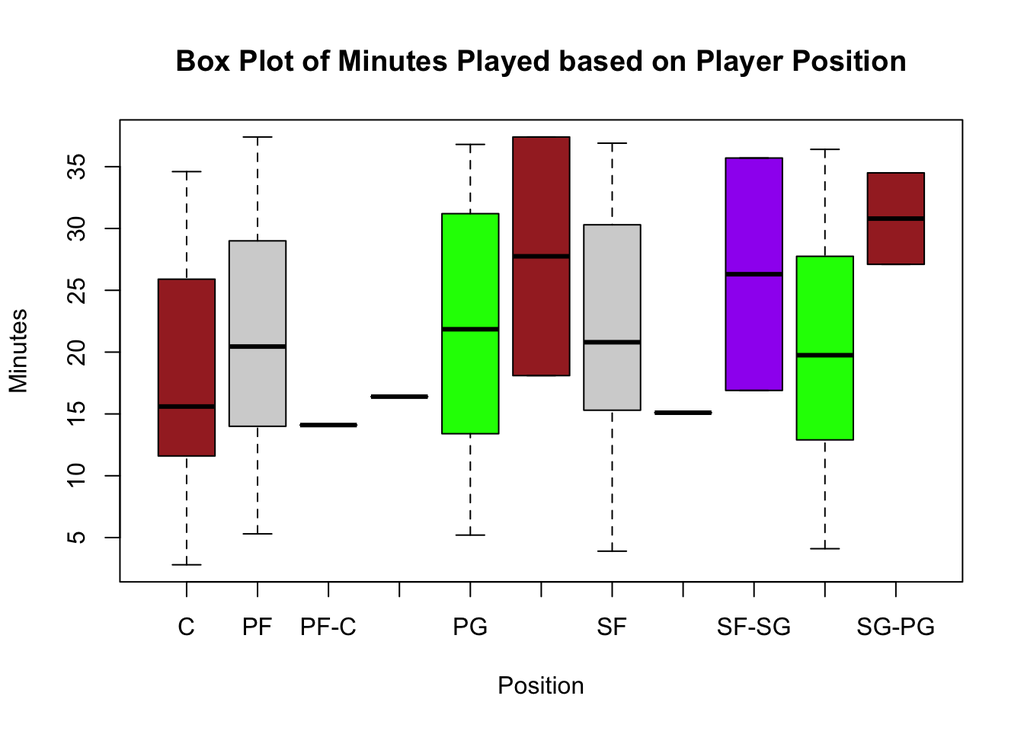

```r
boxplot(nba_five$MP ~ nba_five$Pos, main = "Box Plot of Minutes Played based on Player Position", xlab = "Position", ylab = "Minutes", col = c("brown", "lightgrey", "red", "purple", "green"))
```

4. Using base R and the data set `nba_five`, create a scatter plot of the `AST` (assists) and `TOV` (turnovers) variables, with `AST` represented on the x-axis. Make sure you have an informative title, appropriate axis labels, a `cex = 0.4`, and a black color. From there, include the following elements in your plot, with different aesthetics for each of these elements:
- A point representing the means of both variables
- A point representing the medians of both variables
- A line indicating the top 10$\%$ in the `AST` variable (hint: use quantile function)
- A line indicating the top 10$\%$ in the `TOV` variable (hint: use quantile function)

Include a legend for all elements in your plot, as well as the position types.

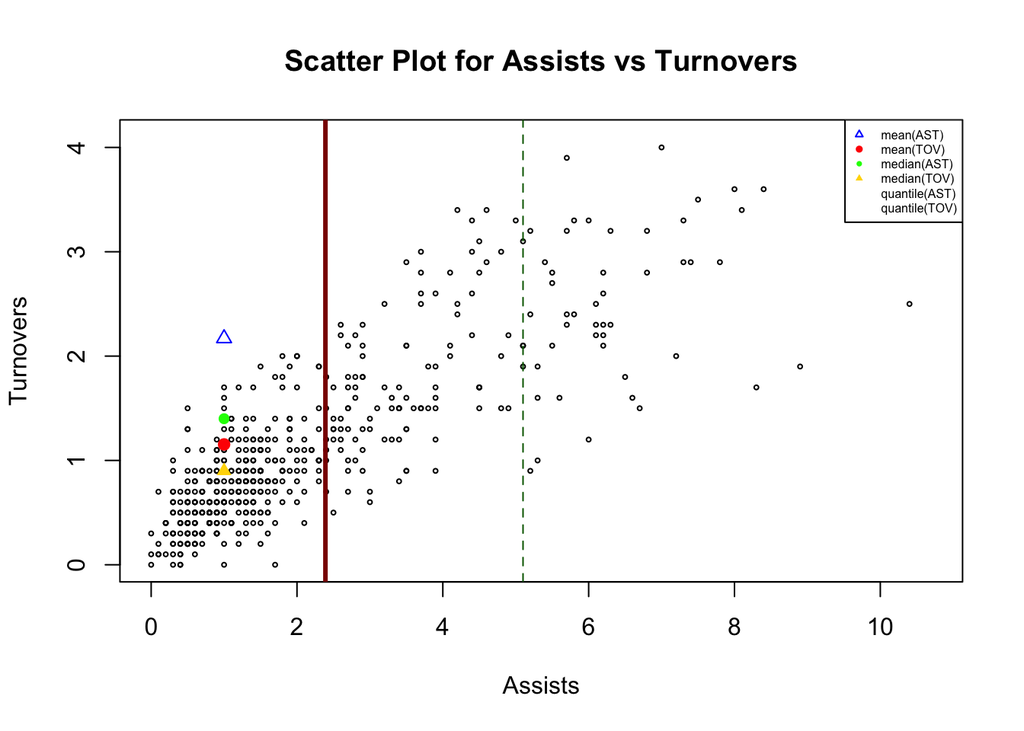

```r
plot(nba_five$AST, nba_five$TOV, main = "Scatter Plot for Assists vs Turnovers", xlab = "Assists", ylab = "Turnovers", cex = 0.4, col = "black")
points(mean(nba_five$AST), col = "blue", pch = 2)
points(mean(nba_five$TOV), col = "red", pch = 19)
points(median(nba_five$AST), col = "green", pch = 16)
points(median(nba_five$TOV), col = "gold", pch = 17)
abline(v = quantile(nba_five$AST, 0.9), col = "darkgreen", lty = 2)
abline(v = quantile(nba_five$TOV, 0.9), col = "darkred", lwd = 3)
legend("topright", legend = c("mean(AST)", "mean(TOV)", "median(AST)", "median(TOV)", "quantile(AST)", "quantile(TOV)"), col = c("blue", "red", "green", "gold", "darkgreen", "darkred"), cex = 0.5, pch = c(2, 19, 16, 17, NA, NA), lty = c(NA, NA, NA, NA, 2, NA), lwd = c(NA, NA, NA, NA, NA, 3))
```

5. Create a histogram of your choice. Make sure you have an informative title and appropriate axis labels. Add vertical lines representing the mean and median of your variable. Include a legend for your plot to label your mean and median.

[figure not shown]

```r
hist(nba_five$STL, main = "Steal Frequency of Five NBA Positions", xlab = "Steal Frequency", ylab = "Count", col = "gold")
abline(v = mean(nba_five$STL), col = "darkgreen", lwd = 3)
abline(v = median(nba_five$STL), col = "purple", lwd = 3)
legend("topright", legend = c("mean(STL)", "mean(STL)"), col = c("darkgreen", "purple"), cex = 0.5, lwd = c(3, 3))
```

**Q3: Apply Functions**

We will continue to use the `nba_five` data set from the previous problem. If you were having trouble creating the `nba_five` data set, using the `nba` data set here is fine.

1. Using `sapply()`, determine the class of the first 10 columns in `nba_five`.

```r
column10 <- sapply(nba_five[, 1:10], class)
column10
```

```
##          Rk      Player         Pos         Age          Tm           G
##   "integer" "character"    "factor"   "integer" "character"   "integer"
##          GS          MP          FG         FGA
##   "integer"   "numeric"   "numeric"   "numeric"
```

2. Create a function named `my_five` that returns a vector of five players, each of which are randomly sampled from the following categories:
- Above the 80th percentile in a particular variable
- Between the 60th and 80th percentile in a particular variable
- Between the 40th and 60th percentile in a particular variable
- Between the 20th and 40th percentile in a particular variable
- Below the 20th percentile in a particular variable

The function should take in two inputs: a vector representing a numerical variable from the `nba_five` data set and a vector representing the column of player names. It should return a vector of five players. (Hint: Start by using the `quantile()` function.)

```r
my_five <- function(nbaVector, playerNamesVector) {
  player5 <- character(5)

  quantile1 <- subset(nba_five, nbaVector > quantile(nbaVector, 0) & nbaVector < quantile(nbaVector, 0.2))
  player5[1] <- sample(quantile1$Player, 1)

  quantile2 <- subset(nba_five, nbaVector > quantile(nbaVector, 0.2) & nbaVector < quantile(nbaVector, 0.4))
  player5[2] <- sample(quantile1$Player, 1)

  quantile1 <- subset(nba_five, nbaVector > quantile(nbaVector, 0.4) & nbaVector < quantile(nbaVector, 0.6))
  player5[3] <- sample(quantile1$Player, 1)

  quantile1 <- subset(nba_five, nbaVector > quantile(nbaVector, 0.6) & nbaVector < quantile(nbaVector, 0.8))
  player5[4] <- sample(quantile1$Player, 1)

  quantile1 <- subset(nba_five, nbaVector > quantile(nbaVector, 0.8) & nbaVector < quantile(nbaVector, 1))
  player5[5] <- sample(quantile1$Player, 1)

  return(player5)
}

ans <- my_five(nba_five$AST, nba_five$Player)
ans
```

```
## [1] "Serge Ibaka"       "Tyrese Martin"     "Jordan Nwora"
## [4] "De'Anthony Melton" "Cameron Payne"
```

```r
nba_five_TOT <- subset(nba_five, Tm == "TOT")
nba_five_TOT
```

```
##      Rk                   Player   Pos Age  Tm  G GS   MP   FG  FGA   FG. X3P
## 6     6 Nickeil Alexander-Walker    SG  24 TOT 59  3 15.0  2.2  5.0 0.444 1.0
## 22   22                 Mo Bamba     C  24 TOT 49  7 15.7  2.4  4.9 0.485 1.0
## 30   30              Will Barton    SG  32 TOT 56  2 17.7  2.5  6.5 0.379 1.2
## 34   34            Darius Bazley     C  22 TOT 43  1 14.3  1.9  4.3 0.454 0.5
## 36   36            Malik Beasley    SG  26 TOT 81 27 25.8  4.6 11.6 0.395 2.9
## 39   39         Patrick Beverley SG-PG  34 TOT 67 67 27.1  2.1  5.4 0.400 1.2
## 40   40               Saddiq Bey    SF  23 TOT 77 37 27.6  4.6 10.9 0.422 2.0
## 42   42             Goga Bitadze     C  23 TOT 38  1 12.0  1.8  3.3 0.552 0.2
## 53   53           Jamaree Bouyea    PG  23 TOT  5  0 14.2  1.2  2.8 0.429 0.4
## 58   58            Mikal Bridges SF-SG  26 TOT 83 83 35.7  7.1 15.3 0.468 2.0
## 70   70            Thomas Bryant     C  25 TOT 59 26 18.3  3.9  6.3 0.623 0.4
## 87   87        Julian Champagnie    SF  21 TOT 17  3 18.8  3.5  7.6 0.454 1.9
## 99   99              Mike Conley    PG  35 TOT 67 66 30.3  3.9  9.1 0.428 2.0
## 115 115           Dewayne Dedmon     C  33 TOT 38  1 11.2  2.0  4.0 0.510 0.3
```

[output cut: 186 more lines]

5. Create a function named `top_player` that finds the player with the highest value of some variable and returns a named list of two elements: the player name and the respective value of that variable. The function should take in two inputs: a vector representing a numerical variable from the `nba_five` data set and a vector representing the column of player names.

```r
top_player <- function(numVector, colVector) {
  max_val <- max(numVector)
  ans <- list(Player = colVector[max_val], Value = max_Val)
}
```

**Q4: Loops and Regression**

1. Create a function named `fib` which has one argument `n`. Have this function generate the first $n$ Fibonacci numbers using a **for** loop. Note that the Fibonacci sequence is formed by starting with the number 0, 1 and then adding the last two numbers to get the next number: 0, 1, 1, 2, 3, 5, 8, etc. Call your function using `n=10` and `n=15`. Assume the user inputs $n > 0$.

```r
fib <- function(n) {
  if (n == 1) {
    print(c(0))
  }

  else if (n == 2) {
    print(c(0, 1))
  }

  else {
    x <- c(0, 1)
    xi <- 0
    for (i in 3:(n + 1)) {
      x <- append(x, (x[xi] + x[xi + 1]))
      xi <- xi + 1
    }
    return(x)
  }
}

fib(10)
```

```
##  [1]  0  1  1  2  3  5  8 13 21 34
```

```r
fib(15)
```

```
##  [1]   0   1   1   2   3   5   8  13  21  34  55  89 144 233 377
```

2. Create a function named `fibNew` which has one argument `n`. Have this function generate the first $n$ Fibonacci numbers using a **while** loop instead. Call your function using `n=10` and `n=15`. Assume the user inputs $n > 0$.

```r
fibNew <- function(n) {
  if (n == 1) {
    print(c(0))
  }

  else if (n == 2) {
    print(c(0, 1))
  }

  else {
    x <- c(0, 1)
    i <- 0
    while (i <= (n - 2)) {
      x <- append(x, (x[i] + x[i + 1]))
      i <- i + 1
    }
    return(x)
  }
}

fibNew(10)
```

```
##  [1]  0  1  1  2  3  5  8 13 21 34
```

```r
fibNew(15)
```

```
##  [1]   0   1   1   2   3   5   8  13  21  34  55  89 144 233 377
```

For the remainder of this question, use the data set `Pokemon.csv` from *Canvas*. This data set comes from [Kaggle.com](https://www.kaggle.com/abcsds/pokemon).

3. Subset the Pokemon dataset such that we only have Pokemon from generation 3. Name this dataset `gen3`.

```r
pokemon <- read.csv("Pokemon.csv")
head(pokemon, 10)
```

```
##    X.                      Name Type.1 Type.2 Total HP Attack Defense Sp..Atk
## 1   1                 Bulbasaur  Grass Poison   318 45     49      49      65
## 2   2                   Ivysaur  Grass Poison   405 60     62      63      80
## 3   3                  Venusaur  Grass Poison   525 80     82      83     100
## 4   3     VenusaurMega Venusaur  Grass Poison   625 80    100     123     122
## 5   4                Charmander   Fire          309 39     52      43      60
## 6   5                Charmeleon   Fire          405 58     64      58      80
## 7   6                 Charizard   Fire Flying   534 78     84      78     109
## 8   6 CharizardMega Charizard X   Fire Dragon   634 78    130     111     130
## 9   6 CharizardMega Charizard Y   Fire Flying   634 78    104      78     159
## 10  7                  Squirtle  Water          314 44     48      65      50
##    Sp..Def Speed Generation Legendary
## 1       65    45          1     False
## 2       80    60          1     False
## 3      100    80          1     False
## 4      120    80          1     False
## 5       50    65          1     False
## 6       65    80          1     False
## 7       85   100          1     False
## 8       85   100          1     False
## 9      115   100          1     False
## 10      64    43          1     False
```

```r
gen3 <- subset(pokemon, Generation == "3")
gen3
```

```
##      X.                    Name   Type.1   Type.2 Total  HP Attack Defense
## 273 252                 Treecko    Grass            310  40     45      35
## 274 253                 Grovyle    Grass            405  50     65      45
## 275 254                Sceptile    Grass            530  70     85      65
## 276 254   SceptileMega Sceptile    Grass   Dragon   630  70    110      75
## 277 255                 Torchic     Fire            310  45     60      40
## 278 256               Combusken     Fire Fighting   405  60     85      60
## 279 257                Blaziken     Fire Fighting   530  80    120      70
## 280 257   BlazikenMega Blaziken     Fire Fighting   630  80    160      80
## 281 258                  Mudkip    Water            310  50     70      50
## 282 259               Marshtomp    Water   Ground   405  70     85      70
## 283 260                Swampert    Water   Ground   535 100    110      90
## 284 260   SwampertMega Swampert    Water   Ground   635 100    150     110
## 285 261               Poochyena     Dark            220  35     55      35
## 286 262               Mightyena     Dark            420  70     90      70
```

[output cut: 307 more lines]